# Biostat M280 Homework 4

(c). Visualize and explain weekly effects.

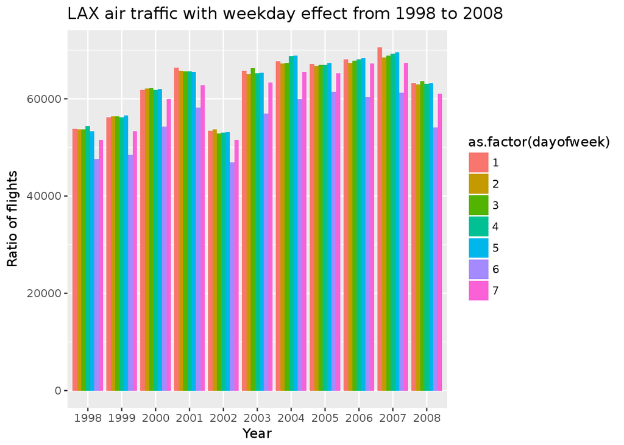

```r
week_LAX <- LAX %>% select(year, dayofweek, origin, dest) %>%
  group_by(year, dayofweek) %>%
  summarize(n = n()) %>%
  collect()

# plot the ratio of flights for weekday in each year
ggplot() +
  geom_col(data = week_LAX, aes(x = as.factor(year),
                                y = n, fill = as.factor(dayofweek)),
           position = "dodge") +
  labs(
    x = "Year",
    y = "Ratio of flights",
    title = "LAX air traffic with weekday effect from 1998 to 2008"
  )
```

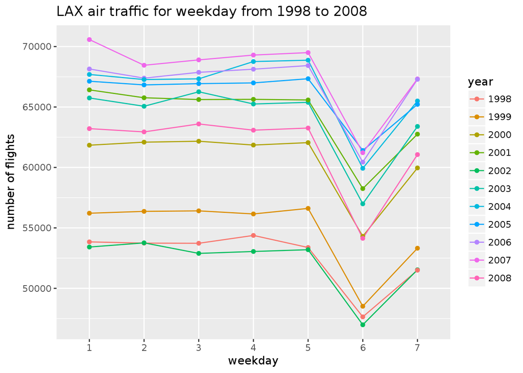

```r
# plot the number of flights according to weekday in each year
ggplot(data = week_LAX, aes(x = as.factor(dayofweek),
                              y = n, colour = as.factor(year),
                              group = as.factor(year))) +
  geom_line() +
  geom_point() +
  labs(
    x = "weekday",
    y = "number of flights",
    title = "LAX air traffic for weekday from 1998 to 2008"
  ) +
  scale_colour_discrete(name = "year")
```

- Select LAX flights data from 1998 to 2008. The above plot reflects the number of flights for seven weekdays in each year. The data from 1998 to 2008 reveal the similar pattern for relation between weekday and number of flights. Saturdays had least number of flights. Possible explanation: most travelers prefer to come back from vacation on Sunday to maximize their time away, thus choosing Sarturday would not be a good idea. Also, during Saturdays, people don’t need to travel for business.
- From Monday to Friday, there were high demands for flights, but between these five weekdays, there are not significant difference. Possible explanation: people need to travel for business during weekdays.